# Phân Tích Thống Kê Nhiều Chiều

11217004_Trương Ngọc Thuỳ Trang

2023-11-26

# Bài tập 1: ANOVA

Tệp số liệu được sử dụng: “HybridTest.xls” Mục tiêu của nghiên cứu là để so sánh các loại xe ô tô điện và xe xăng truyền thống.

Consumer Số liệu sau đây là số đo về lượng tiêu hao năng lượng đo bằng dặm/gallon (MPG) cho hai mẫu xe điện cỡ nhỏ, hai mẫu xe điện cỡ trung, hai mẫu xe điện SUV cỡ nhỏ và hai mẫu xe điện SUV cỡ trung. Tương tự là MPG cho tám mẫu xe xăng thông thường.

1. Thực hiện một số thống kê mô tả và nhận xét.

2. Với mức ý nghĩa $\alpha = 0.05$, hãy kiểm định các tác động do loại xe, cỡ xe và tương tác giữa loại xe và cỡ xe.

3. Thực hiện các kiểm định so sánh cặp (multiple comparison).

```r
library(readxl)
HybridTest <- read_excel("Assignment_TKT63/HybridTest.xlsx")
HybridTest
```

```
## # A tibble: 16 × 4
##    `Make/Model`      Class       Type           MPG
##    <chr>             <chr>       <chr>        <dbl>
##  1 Honda Civic       Small Car   Hybrid          37
##  2 Honda Civic       Small Car   Conventional    28
##  3 Toyota Prius      Small Car   Hybrid          44
##  4 Toyota Corolla    Small Car   Conventional    32
##  5 Chevrolet Malibu  Midsize Car Hybrid          27
##  6 Chevrolet Malibu  Midsize Car Conventional    23
##  7 Nissan Altima     Midsize Car Hybrid          32
##  8 Nissan Altima     Midsize Car Conventional    25
##  9 Ford Escape       Small SUV   Hybrid          27
## 10 Ford Escape       Small SUV   Conventional    21
## 11 Saturn Vue        Small SUV   Hybrid          28
## 12 Saturn Vue        Small SUV   Conventional    22
## 13 Lexus RX          Midsize SUV Hybrid          23
## 14 Lexus RX          Midsize SUV Conventional    19
## 15 Toyota Highlander Midsize SUV Hybrid          24
## 16 Toyota Highlander Midsize SUV Conventional    18
```

## 1.1. Thực hiện một số thống kê mô tả và nhận xét

```r
#summary(HybridTest)
class<-as.factor(HybridTest$Class)
type<- as.factor(HybridTest$Type)
MPG<-HybridTest$MPG
summary(class)
```

```
## Midsize Car Midsize SUV   Small Car   Small SUV
##           4           4           4           4
```

```r
summary(type)
```

```
## Conventional       Hybrid
##            8            8
```

```r
summary(MPG)
```

```
##    Min. 1st Qu.  Median    Mean 3rd Qu.    Max.
##   18.00   22.75   26.00   26.88   29.00   44.00
```

```r
print("Trung bình MPG của mẫu xe cỡ nhỏ")
```

```
## [1] "Trung bình MPG của mẫu xe cỡ nhỏ"
```

```r
mean(MPG[1:4])
```

```
## [1] 35.25
```

```r
print("Trung bình MPG của mẫu xe cỡ vừa")
```

```
## [1] "Trung bình MPG của mẫu xe cỡ vừa"
```

```r
mean(MPG[5:8])
```

```
## [1] 26.75
```

```r
print("Trung bình MPG của mẫu xe cỡ nhỏ SUV")
```

```
## [1] "Trung bình MPG của mẫu xe cỡ nhỏ SUV"
```

```r
mean(MPG[9:12])
```

```
## [1] 24.5
```

```r
print("Trung bình MPG của mẫu xe cỡ vừa SUV")
```

```
## [1] "Trung bình MPG của mẫu xe cỡ vừa SUV"
```

```r
mean(MPG[13:16])
```

```
## [1] 21
```

### Các giả thiết ANOVA:

-Mẫu là ngẫu nhiên và độc lập

-Biến phụ thuộc phân phối chuẩn

-Phương sai biến phụ thuộc trong mỗi nhóm là tương đồng

### Kiểm định các giả thiết ANOVA

a.Mẫu là ngẫu nhiên và độc lập

b.Biến phụ thuộc phân phối chuẩn

```r
library(nortest)
## Kiểm định thông qua sai số
AV=rstandard(aov(MPG~class*type))
shapiro.test(AV)
```

```
##
##  Shapiro-Wilk normality test
##
## data:  AV
## W = 0.9729, p-value = 0.8831
```

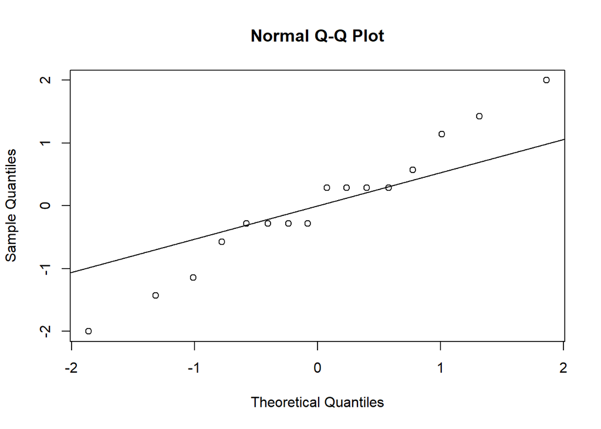

```r
# qqplot of residuals
qqnorm(AV)
qqline(AV)
```

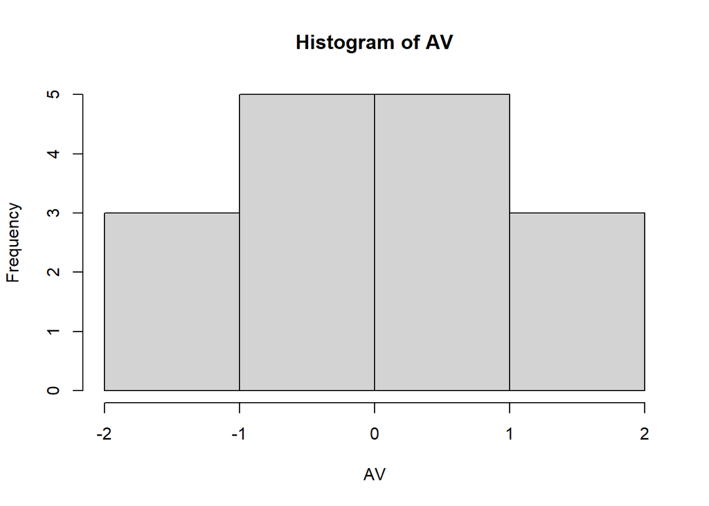

```r
# Histogram of residuals
hist(AV)
```

c. Phương sai biến phụ thuộc trong mỗi nhóm là tương đồng

```r
library(car)
leveneTest(MPG~class*type,data=HybridTest)
```

```
## Levene's Test for Homogeneity of Variance (center = median)
##       Df    F value    Pr(>F)
## group  7 1.0973e+31 < 2.2e-16 ***
##        8
## ---
## Signif. codes:  0 '***' 0.001 '**' 0.01 '*' 0.05 '.' 0.1 ' ' 1
```

=> Phương sai trong mỗi nhóm không tương đồng. Nhưng ANOVA vẫn có thể dùng khi kích cỡ mẫu của các nhóm là bằng nhau.

## 1.2. Với mức ý nghĩa $\alpha = 0.05$, hãy kiểm định các tác động do loại xe, cỡ xe và tương tác giữa loại xe và cỡ xe.

```r
anova_MPG<-aov(MPG~class+type+class*type,data = HybridTest)
summary(anova_MPG)
```

```
##             Df Sum Sq Mean Sq F value   Pr(>F)
## class        3  441.3  147.08  24.014 0.000236 ***
## type         1  182.2  182.25  29.755 0.000605 ***
## class:type   3   19.3    6.42   1.048 0.422860
## Residuals    8   49.0    6.13
## ---
## Signif. codes:  0 '***' 0.001 '**' 0.01 '*' 0.05 '.' 0.1 ' ' 1
```

=>Nhân tố cỡ xe và loại xe có tác động đến trung bình => Ít nhất một trung bình của 1 nhóm có sự khác biệt =>Kiểm tra bằng Tukey Test

=>Nhưng tương tác giữa cỡ xe và loại xe thì lại không tác động đến trung bình

## 1.3. Thực hiện các kiểm định so sánh cặp (multiple comparison).

Dùng kiểm định Tukey

$H_0$:Trung bình của 2 nhóm tương đồng

$H_1$:Trung bình của 2 nhóm có sự khác biệt

Ở trường hợp này chỉ cần kiểm định so sánh cặp cho nhân tố cỡ xe vì nhân tố loại xe chỉ có 2 nhóm.

```r
library(stats)
TukeyHSD(anova_MPG,c("class"),ordered = FALSE)
```

```
##   Tukey multiple comparisons of means
##     95% family-wise confidence level
##
## Fit: aov(formula = MPG ~ class + type + class * type, data = HybridTest)
##
## $class
##                           diff        lwr       upr     p adj
## Midsize SUV-Midsize Car  -5.75 -11.354116 -0.145884 0.0444736
## Small Car-Midsize Car     8.50   2.895884 14.104116 0.0055113
## Small SUV-Midsize Car    -2.25  -7.854116  3.354116 0.5956797
## Small Car-Midsize SUV    14.25   8.645884 19.854116 0.0001773
## Small SUV-Midsize SUV     3.50  -2.104116  9.104116 0.2640524
## Small SUV-Small Car     -10.75 -16.354116 -5.145884 0.0012450
```

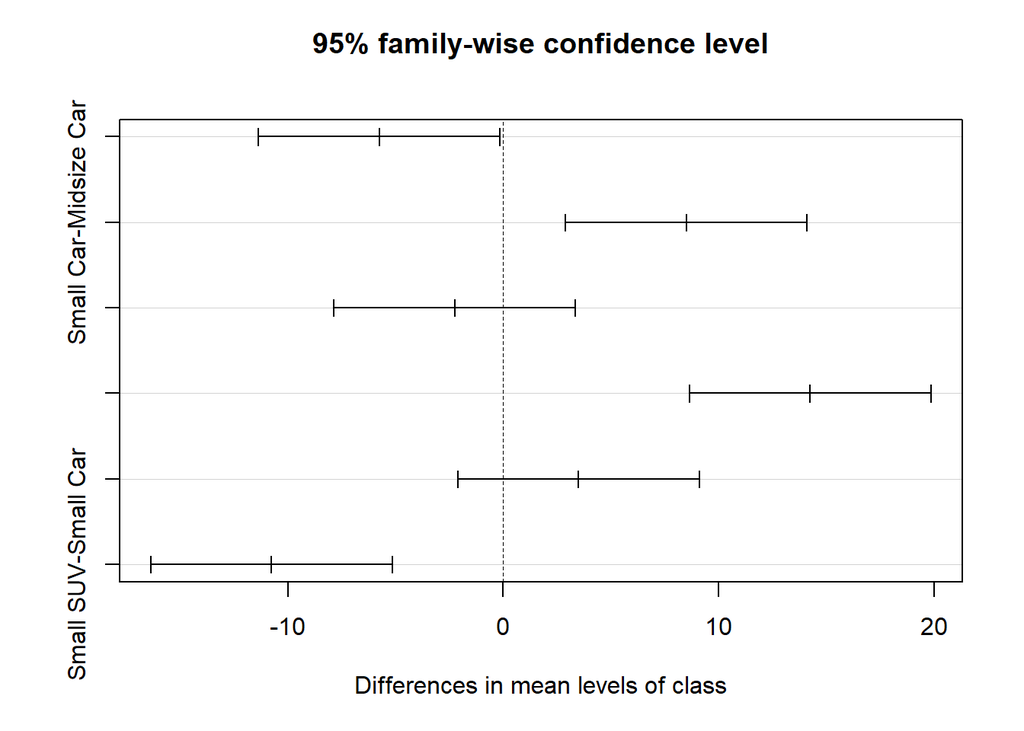

```r
plot(TukeyHSD(anova_MPG,c("class"),ordered = FALSE))
```

# Bài tập 2: PCA và phân tích nhân tố

Dữ liệu được sử dụng: “car_sale”. -Tệp dữ liệu này chứa các biến về doanh số(sales), giá niêm yết(price) và thông số kỹ thuật cho các kiểu dáng và mẫu xe khác nhau. (nhãn của các biến trong bảng “nhãn”). Một nhà phân tích muốn dự đoán doanh số bán ô tô từ một tập hợp các yếu tố đã cho. Tuy nhiên, nhiều yếu tố có mối tương quan với nhau và nhà phân tích lo ngại rằng điều này có thể ảnh hưởng xấu đến kết quả phân tích. Yêu cầu: Sử dụng Phân tích nhân tố với PCA để phân tích các yếu tố ảnh hưởng đến giá bán.

```r
library(readxl)
car_sales <- read_excel("Assignment_TKT63/car_sales.xlsx")
car_sales<-data.frame(car_sales)
```

Nhận thấy dữ liệu đầu vào bị khuyết giá trị, cột thứ 14 là giá trị ln(sales),từ cột 15 đến cột 25 là các giá trị chuẩn hoá của cột 3 đến cột 13 =>Cách xử lý???

## 2.1.Xử lý dữ liệu

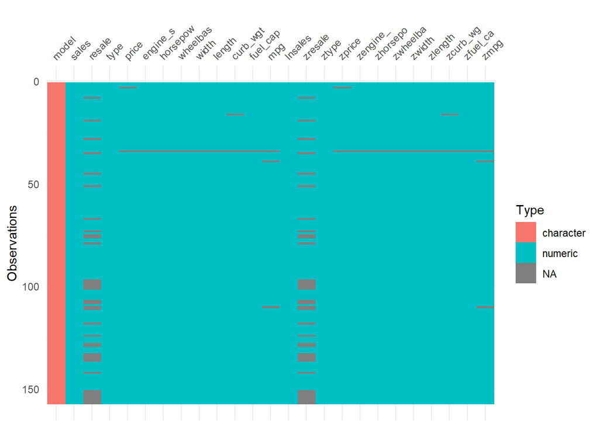

```r
## Visualization missing values
library(visdat)
vis_dat(car_sales)
```

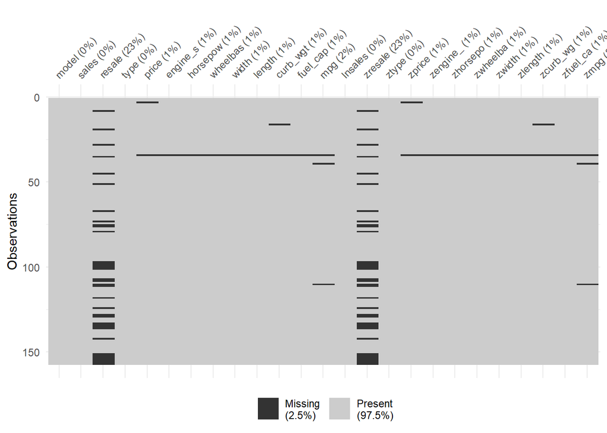

```r
vis_miss(car_sales)
```

-Cách 1:Bỏ tất cả các dòng bị thiếu giá trị

```r
car_sales1<-na.omit(car_sales)
head(car_sales1)
```

```
##     model  sales resale type price engine_s horsepow wheelbas width length
## 1 Integra 16.919 16.360    0 21.50      1.8      140    101.2  67.3  172.4
## 2      TL 39.384 19.875    0 28.40      3.2      225    108.1  70.3  192.9
## 4      RL  8.588 29.725    0 42.00      3.5      210    114.6  71.4  196.6
## 5      A4 20.397 22.255    0 23.99      1.8      150    102.6  68.2  178.0
## 6      A6 18.780 23.555    0 33.95      2.8      200    108.7  76.1  192.0
## 7      A8  1.380 39.000    0 62.00      4.2      310    113.0  74.0  198.2
##   curb_wgt fuel_cap mpg   lnsales    zresale      ztype      zprice   zengine_
## 1    2.639     13.2  28 2.8284373 -0.1495606 -0.5926188 -0.41045828 -1.2070012
## 2    3.517     17.2  25 3.6733596  0.1573356 -0.5926188  0.07032257  0.1331567
## 4    3.850     18.0  22 2.1503659  1.0173434 -0.5926188  1.01794859  0.4203334
## 5    2.998     16.4  27 3.0153878  0.3651344 -0.5926188 -0.23695910 -1.2070012
## 6    3.561     18.5  22 2.9327925  0.4786380 -0.5926188  0.45703760 -0.2497456
## 7    3.902     23.7  21 0.3220835  1.8271477 -0.5926188  2.41151627  1.0904124
##     zhorsepo    zwheelba      zwidth    zlength   zcurb_wg    zfuel_ca
## 1 -0.8103784 -0.82278892 -1.11533688 -1.1125568 -1.1721235 -1.22222719
## 2  0.6887312  0.08019843 -0.24624321  0.4136772  0.2204185 -0.19339977
## 4  0.4241825  0.93083869  0.07242447  0.6891438  0.7485693  0.01236571
## 5 -0.6340126 -0.63957410 -0.85460878 -0.6956344 -0.6027356 -0.39916525
## 6  0.2478166  0.15871907  1.43400456  0.3466718  0.2902042  0.14096914
## 7  2.1878409  0.72145032  0.82563899  0.8082645  0.8310434  1.47844479
##         zmpg
## 1  0.9705266
## 2  0.2700372
## 4 -0.4304523
## 5  0.7370301
## 6 -0.4304523
## 7 -0.6639487
```

-Cách 2: Thay những giá trị N/A bằng trung bình của biến đó

```r
car_salesM<-car_sales[,1:13]
car_sales2=data.frame()
for(i in 2:ncol(car_salesM)) {
  mv<-is.na(car_salesM[,i])
  car_salesM[mv,i]=mean(car_sales[,i],na.rm = TRUE)
}
head(car_salesM)
```

```
##     model  sales resale type    price engine_s horsepow wheelbas width length
## 1 Integra 16.919 16.360    0 21.50000      1.8      140    101.2  67.3  172.4
## 2      TL 39.384 19.875    0 28.40000      3.2      225    108.1  70.3  192.9
## 3      CL 14.114 18.225    0 27.39075      3.2      225    106.9  70.6  192.0
## 4      RL  8.588 29.725    0 42.00000      3.5      210    114.6  71.4  196.6
## 5      A4 20.397 22.255    0 23.99000      1.8      150    102.6  68.2  178.0
## 6      A6 18.780 23.555    0 33.95000      2.8      200    108.7  76.1  192.0
##   curb_wgt fuel_cap mpg
## 1    2.639     13.2  28
## 2    3.517     17.2  25
## 3    3.470     17.2  26
## 4    3.850     18.0  22
## 5    2.998     16.4  27
## 6    3.561     18.5  22
```

-Cách 3:Hồi quy (regression impution)

-Cách 4:Stochatic regression imputation (Hồi quy có tính đến yếu tố ngẫu nhiên)

-Cách 5: K-Nearest Neighbors:Algorithm

Để đơn giản hoá việc tính toán và phân tích và mẫu cũng đủ lớn nên trong trường hợp này sẽ lấy tập dữ liệu sau khi đã bỏ các dòng có quan sát bị thiếu.

## 2.2.Phân tích thành phần chính (PCA)

Vì nhà phân tích muốn dự đoán doanh số bán ô tô từ một tập hợp các yếu tố đã cho. Tuy nhiên, nhiều yếu tố có mối tương quan với nhau và nhà phân tích lo ngại rằng điều này có thể ảnh hưởng xấu đến kết quả phân tích. Do đó sẽ sử dụng phân tích thành phần chính PCA để chọn ra các thành phần đại diện quan trọng nhất ảnh hưởng đến giá bán.

```r
library(FactoMineR)
library(factoextra)
sales_PCA<-na.omit(car_sales1[,15:25])
head(sales_PCA)
```

```
##      zresale      ztype      zprice   zengine_   zhorsepo    zwheelba
## 1 -0.1495606 -0.5926188 -0.41045828 -1.2070012 -0.8103784 -0.82278892
## 2  0.1573356 -0.5926188  0.07032257  0.1331567  0.6887312  0.08019843
## 4  1.0173434 -0.5926188  1.01794859  0.4203334  0.4241825  0.93083869
## 5  0.3651344 -0.5926188 -0.23695910 -1.2070012 -0.6340126 -0.63957410
## 6  0.4786380 -0.5926188  0.45703760 -0.2497456  0.2478166  0.15871907
## 7  1.8271477 -0.5926188  2.41151627  1.0904124  2.1878409  0.72145032
##        zwidth    zlength   zcurb_wg    zfuel_ca       zmpg
## 1 -1.11533688 -1.1125568 -1.1721235 -1.22222719  0.9705266
## 2 -0.24624321  0.4136772  0.2204185 -0.19339977  0.2700372
## 4  0.07242447  0.6891438  0.7485693  0.01236571 -0.4304523
## 5 -0.85460878 -0.6956344 -0.6027356 -0.39916525  0.7370301
## 6  1.43400456  0.3466718  0.2902042  0.14096914 -0.4304523
## 7  0.82563899  0.8082645  0.8310434  1.47844479 -0.6639487
```

```r
cov1=cov(sales_PCA)
#head(cov1)
cov = matrix(cov1,nrow =11,ncol =11)
head(cov)
```

```
##             [,1]        [,2]        [,3]      [,4]        [,5]        [,6]
## [1,]  1.02676239 -0.09141393  0.95383487 0.5395727  0.80952017 -0.05731186
## [2,] -0.09141393  0.96832072 -0.07402802 0.1814089 -0.04663999  0.39920870
## [3,]  0.95383487 -0.07402802  0.97205438 0.6464783  0.86951525  0.06963929
## [4,]  0.53957269  0.18140887  0.64647832 1.0202347  0.89932395  0.43632998
## [5,]  0.80952017 -0.04663999  0.86951525 0.8993240  1.06783078  0.24594418
## [6,] -0.05731186  0.39920870  0.06963929 0.4363300  0.24594418  1.10999325
##           [,7]       [,8]      [,9]     [,10]      [,11]
## [1,] 0.1845894 0.02652892 0.3486472 0.3212147 -0.4158699
## [2,] 0.2221448 0.11138980 0.4373487 0.5636936 -0.5454971
## [3,] 0.3037886 0.18562725 0.4775539 0.3911573 -0.4865939
## [4,] 0.6939053 0.55964982 0.7106511 0.6081177 -0.7528867
## [5,] 0.5360842 0.42724326 0.5858776 0.4838958 -0.6333072
## [6,] 0.7278836 0.92739382 0.6741744 0.6772786 -0.5099582
```

```r
eigen(cov1) #Tìm các giá trị riêng,vecto riêng
```

```
## eigen() decomposition
## $values
##  [1] 6.22090540 2.43225524 1.18734513 0.44734164 0.26985914 0.21254997
##  [7] 0.12851463 0.12529446 0.07890975 0.05683943 0.02166234
##
## $vectors
##             [,1]        [,2]        [,3]        [,4]         [,5]        [,6]
##  [1,]  0.2144486 -0.50796494 -0.08924184  0.40786483 -0.174342821 -0.08241042
##  [2,]  0.1455674  0.30256229 -0.67233251  0.05382222  0.137043323 -0.51413409
##  [3,]  0.2570336 -0.45135416 -0.01277015  0.31570331 -0.057980625 -0.04363691
##  [4,]  0.3532062 -0.14243471  0.06475854 -0.50040699  0.336261267 -0.28642382
##  [5,]  0.3244407 -0.35796177  0.12932466 -0.18408065  0.264355092 -0.18084377
##  [6,]  0.2847208  0.40114380  0.22727948  0.46459469  0.206414079 -0.20713813
##  [7,]  0.3295342  0.17363213  0.25570938 -0.32307424 -0.745867265 -0.25724933
##  [8,]  0.2959577  0.27444531  0.46833960  0.15689691  0.265805305  0.17061616
##  [9,]  0.3513003  0.09632220 -0.08586668  0.05026141 -0.007793297  0.18847309
## [10,]  0.3351418  0.14667905 -0.25131528  0.18148427 -0.290318848  0.20679628
## [11,] -0.3517921 -0.03324788  0.33467236  0.25784383 -0.102877221 -0.62908450
##             [,7]        [,8]        [,9]       [,10]       [,11]
##  [1,]  0.1124614 -0.21899677 -0.01163964  0.27908741  0.58808697
##  [2,]  0.2382821 -0.04679655  0.29547773  0.03874024 -0.03804548
##  [3,]  0.1916340  0.12908105 -0.04042168  0.07247946 -0.75156030
##  [4,] -0.2180485  0.13919562 -0.30838804  0.49284237  0.01814596
##  [5,] -0.1849605 -0.12826904  0.32497543 -0.67072932  0.08516330
##  [6,] -0.1024043 -0.29922745 -0.51752242 -0.19120578 -0.02424380
##  [7,]  0.2037871 -0.15401138  0.01120480 -0.04613152 -0.03869524
##  [8,]  0.1973529  0.01900252  0.58659771  0.33112117  0.01790277
##  [9,]  0.3082611  0.73863380 -0.20805539 -0.25898202  0.26620383
## [10,] -0.7590285  0.14324984  0.19123836  0.08312982 -0.05377857
## [11,] -0.2235662  0.46652133  0.13527852  0.01653671  0.06418018
```

```r
11*mean(eigen(cov1)$values)
```

```
## [1] 11.18148
```

```r
x<-diag(cov1)
sum(x)
```

```
## [1] 11.18148
```

```r
#Tổng các giá trị riêng bằng tổng giá trị var
```

```r
pca<-PCA(sales_PCA,graph=FALSE)
#print(pca)
get_eigenvalue(pca)
```

```
##        eigenvalue variance.percent cumulative.variance.percent
## Dim.1  6.14307118       55.8461017                    55.84610
## Dim.2  2.37062900       21.5511727                    77.39727
## Dim.3  1.17369462       10.6699511                    88.06723
## Dim.4  0.43036424        3.9124022                    91.97963
## Dim.5  0.26016842        2.3651675                    94.34480
## Dim.6  0.20845349        1.8950317                    96.23983
## Dim.7  0.13483868        1.2258062                    97.46563
## Dim.8  0.12747259        1.1588417                    98.62447
## Dim.9  0.07482681        0.6802437                    99.30472
## Dim.10 0.05453537        0.4957761                    99.80049
## Dim.11 0.02194559        0.1995054                   100.00000
```

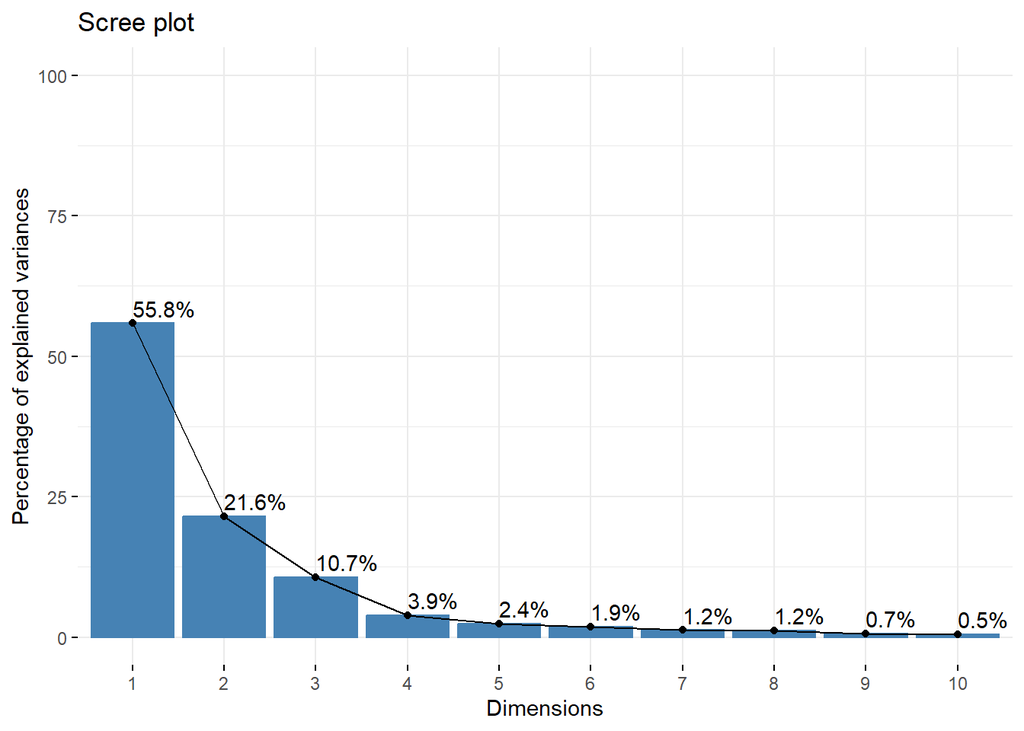

```r
## Trực quan tỉ lệ các thành phần chính
fviz_eig(pca,addlabels = TRUE,ylim=c(0,100))
```

```r
PCA_s=prcomp(sales_PCA)
summary(PCA_s)
```

```
## Importance of components:
##                           PC1    PC2    PC3     PC4     PC5     PC6     PC7
## Standard deviation     2.4942 1.5596 1.0897 0.66884 0.51948 0.46103 0.35849
## Proportion of Variance 0.5564 0.2175 0.1062 0.04001 0.02413 0.01901 0.01149
## Cumulative Proportion  0.5564 0.7739 0.8801 0.92008 0.94421 0.96322 0.97472
##                            PC8     PC9    PC10    PC11
## Standard deviation     0.35397 0.28091 0.23841 0.14718
## Proportion of Variance 0.01121 0.00706 0.00508 0.00194
## Cumulative Proportion  0.98592 0.99298 0.99806 1.00000
```

```r
PCA_sales=princomp(sales_PCA,cor=TRUE,score=TRUE)
summary(PCA_sales)
```

```
## Importance of components:
##                          Comp.1    Comp.2    Comp.3     Comp.4     Comp.5
## Standard deviation     2.478522 1.5396847 1.0833719 0.65602152 0.51006708
## Proportion of Variance 0.558461 0.2155117 0.1066995 0.03912402 0.02365167
## Cumulative Proportion  0.558461 0.7739727 0.8806723 0.91979628 0.94344795
##                            Comp.6     Comp.7     Comp.8      Comp.9     Comp.10
## Standard deviation     0.45656707 0.36720387 0.35703304 0.273544897 0.233528085
## Proportion of Variance 0.01895032 0.01225806 0.01158842 0.006802437 0.004957761
## Cumulative Proportion  0.96239827 0.97465633 0.98624475 0.993047185 0.998004946
##                            Comp.11
## Standard deviation     0.148140455
## Proportion of Variance 0.001995054
## Cumulative Proportion  1.000000000
```

```r
#(PCA_s$sdev)^2
(PCA_sales$sdev)^2
```

```
##     Comp.1     Comp.2     Comp.3     Comp.4     Comp.5     Comp.6     Comp.7
## 6.14307118 2.37062900 1.17369462 0.43036424 0.26016842 0.20845349 0.13483868
##     Comp.8     Comp.9    Comp.10    Comp.11
## 0.12747259 0.07482681 0.05453537 0.02194559
```

Có 3 giá trị eigen>1. Giữ lại PC1,PC2,PC3 chúng chiếm 88.01% tổng phương sai

```r
PCA_s
```

```
## Standard deviations (1, .., p=11):
##  [1] 2.4941743 1.5595689 1.0896537 0.6688360 0.5194797 0.4610314 0.3584894
##  [8] 0.3539696 0.2809088 0.2384102 0.1471813
##
## Rotation (n x k) = (11 x 11):
##                 PC1         PC2         PC3         PC4          PC5
## zresale   0.2144486  0.50796494 -0.08924184 -0.40786483  0.174342821
## ztype     0.1455674 -0.30256229 -0.67233251 -0.05382222 -0.137043323
## zprice    0.2570336  0.45135416 -0.01277015 -0.31570331  0.057980625
## zengine_  0.3532062  0.14243471  0.06475854  0.50040699 -0.336261267
## zhorsepo  0.3244407  0.35796177  0.12932466  0.18408065 -0.264355092
## zwheelba  0.2847208 -0.40114380  0.22727948 -0.46459469 -0.206414079
## zwidth    0.3295342 -0.17363213  0.25570938  0.32307424  0.745867265
## zlength   0.2959577 -0.27444531  0.46833960 -0.15689691 -0.265805305
## zcurb_wg  0.3513003 -0.09632220 -0.08586668 -0.05026141  0.007793297
## zfuel_ca  0.3351418 -0.14667905 -0.25131528 -0.18148427  0.290318848
## zmpg     -0.3517921  0.03324788  0.33467236 -0.25784383  0.102877221
##                  PC6        PC7         PC8         PC9        PC10        PC11
## zresale  -0.08241042 -0.1124614 -0.21899677  0.01163964 -0.27908741  0.58808697
## ztype    -0.51413409 -0.2382821 -0.04679655 -0.29547773 -0.03874024 -0.03804548
## zprice   -0.04363691 -0.1916340  0.12908105  0.04042168 -0.07247946 -0.75156030
## zengine_ -0.28642382  0.2180485  0.13919562  0.30838804 -0.49284237  0.01814596
## zhorsepo -0.18084377  0.1849605 -0.12826904 -0.32497543  0.67072932  0.08516330
## zwheelba -0.20713813  0.1024043 -0.29922745  0.51752242  0.19120578 -0.02424380
## zwidth   -0.25724933 -0.2037871 -0.15401138 -0.01120480  0.04613152 -0.03869524
## zlength   0.17061616 -0.1973529  0.01900252 -0.58659771 -0.33112117  0.01790277
## zcurb_wg  0.18847309 -0.3082611  0.73863380  0.20805539  0.25898202  0.26620383
## zfuel_ca  0.20679628  0.7590285  0.14324984 -0.19123836 -0.08312982 -0.05377857
## zmpg     -0.62908450  0.2235662  0.46652133 -0.13527852 -0.01653671  0.06418018
```

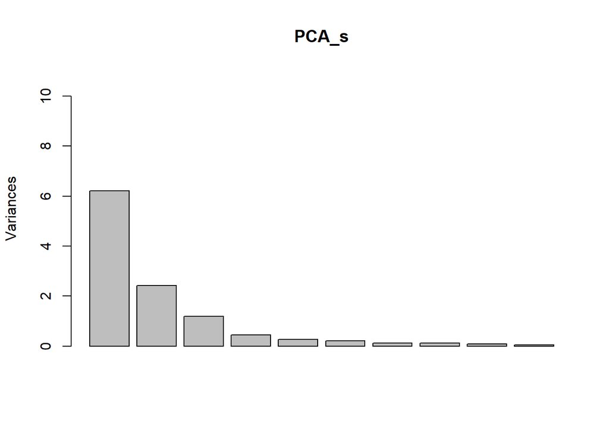

```r
plot(PCA_s,ylim=c(0,11))
```

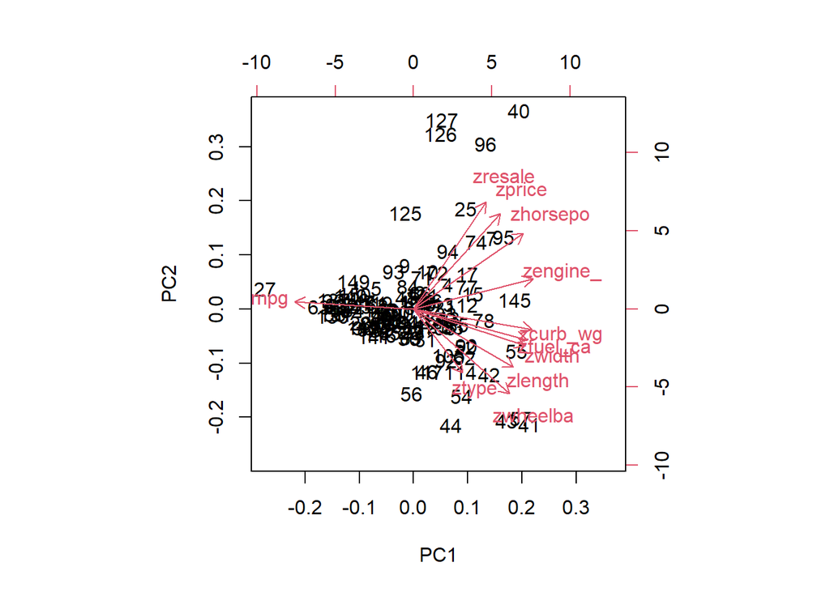

```r
biplot(PCA_s)
```

```r
PC<-PCA_s$x
# Giữ lại 3 nhân tố PC1,PC2,PC3
sales_PCA1<-cbind(sales_PCA,PC[,1:3])
zsale<-scale(na.omit(car_sales1$sales))
sales_PCA1<-cbind(zsale,sales_PCA1)
head(sales_PCA1)
```

```
##        zsale    zresale      ztype      zprice   zengine_   zhorsepo
## 1 -0.5621358 -0.1495606 -0.5926188 -0.41045828 -1.2070012 -0.8103784
## 2 -0.2628377  0.1573356 -0.5926188  0.07032257  0.1331567  0.6887312
## 4 -0.6731286  1.0173434 -0.5926188  1.01794859  0.4203334  0.4241825
## 5 -0.5157989  0.3651344 -0.5926188 -0.23695910 -1.2070012 -0.6340126
## 6 -0.5373420  0.4786380 -0.5926188  0.45703760 -0.2497456  0.2478166
## 7 -0.7691598  1.8271477 -0.5926188  2.41151627  1.0904124  2.1878409
##      zwheelba      zwidth    zlength   zcurb_wg    zfuel_ca       zmpg
## 1 -0.82278892 -1.11533688 -1.1125568 -1.1721235 -1.22222719  0.9705266
## 2  0.08019843 -0.24624321  0.4136772  0.2204185 -0.19339977  0.2700372
## 4  0.93083869  0.07242447  0.6891438  0.7485693  0.01236571 -0.4304523
## 5 -0.63957410 -0.85460878 -0.6956344 -0.6027356 -0.39916525  0.7370301
## 6  0.15871907  1.43400456  0.3466718  0.2902042  0.14096914 -0.4304523
## 7  0.72145032  0.82563899  0.8082645  0.8310434  1.47844479 -0.6639487
##          PC1       PC2         PC3
## 1 -2.8869768 0.6636894 -0.08604204
## 2  0.3377639 0.5237653  0.69078313
## 4  1.7110255 0.7580352  0.65865187
## 5 -1.8552997 0.6500557 -0.14169294
## 6  1.1669996 0.2652416  0.66701500
## 7  3.8780663 2.2149149  0.58719386
```

## 2.3.Đánh giá tác động của các thành phần chính lên doanh số

```r
library(lmtest)
library(stargazer)
reg = lm(zsale~PC1+PC2+PC3,data=sales_PCA1)
stargazer(reg,type = "text")
```

```
##
## ===============================================
##                         Dependent variable:
##                     ---------------------------
##                                zsale
## -----------------------------------------------
## PC1                            0.038
##                               (0.034)
##
## PC2                          -0.286***
##                               (0.054)
##
## PC3                            0.033
##                               (0.077)
##
## Constant                      -0.000
##                               (0.083)
##
## -----------------------------------------------
## Observations                    117
## R2                             0.210
## Adjusted R2                    0.189
## Residual Std. Error      0.901 (df = 113)
## F Statistic           9.990*** (df = 3; 113)
## ===============================================
## Note:               *p<0.1; **p<0.05; ***p<0.01
```

# Bài tập 3: Phân tích cụm (Cluster Analysis)

Các nhà sản xuất ô tô cần có khả năng đánh giá thị trường hiện tại để xác định khả năng cạnh tranh cho xe của họ. Nếu ô tô có thể được nhóm theo dữ liệu có sẵn thì việc này sẽ có thể được thực hiện tự động bằng cách sử dụng phân tích cụm.

Thông tin về các kiểu dáng và nhãn hiệu xe khác nhau có trong tập dự liệu “car_sale” (giống như dữ liệu cho Bài tập 2). Sử dụng quy trình Phân tích cụm phân cấp (hierarchical) để nhóm các loại ô tô bán chạy nhất theo giá cả và đặc tính kĩ thuật của chúng.

```r
library(readxl)
car_sales <- read_excel("Assignment_TKT63/car_sales.xlsx",)
# Tạo một bảng dữ liệu mới chỉ lấy từ cột 1 đến cột 13 vì những cột còn lại là giá trị chuẩn hoá
car_sales<-data.frame(car_sales[,1:13])
library(factoextra)
library(cluster)
## Loại dòng mà bị mất giá trị
data<-na.omit(car_sales)

## Chuẩn hoá dữ liệu
data[,-1]<-scale(data[,-1])
head(data)
```

```
##     model      sales     resale      type      price   engine_s   horsepow
## 1 Integra -0.5621358 -0.1440282 -0.571602 -0.3158715 -1.1834292 -0.7045706
## 2      TL -0.2628377  0.1588420 -0.571602  0.1717713  0.1433723  0.7461447
## 4      RL -0.6731286  1.0075678 -0.571602  1.1329225  0.4276869  0.4901361
## 5      A4 -0.5157989  0.3639148 -0.571602 -0.1398961 -1.1834292 -0.5338982
## 6      A6 -0.5373420  0.4759294 -0.571602  0.5640058 -0.2357138  0.3194637
## 7      A8 -0.7691598  1.8067488 -0.571602  2.5463801  1.0910877  2.1968600
##      wheelbas       width     length   curb_wgt    fuel_cap        mpg
## 1 -0.76099980 -1.10186337 -1.1059950 -1.1471500 -1.21562468  0.8814503
## 2  0.09608047 -0.25204126  0.3741573  0.3231015 -0.16149767  0.2002767
## 4  0.90347493  0.05956018  0.6413068  0.8807254  0.04932774 -0.4808969
## 5 -0.58709946 -0.84691674 -0.7016607 -0.5459879 -0.37232307  0.6543924
## 6  0.17060919  1.39094816  0.3091750  0.3967816  0.18109362 -0.4808969
## 7  0.70473168  0.79607268  0.7568308  0.9678018  1.55145874 -0.7079548
```

## 3.1.Phương pháp phân cụm khoảng cách liên kết (linkage method) phù hợp

```r
m<-c("average","single","complete","ward")
names(m)<-c("average","single","complete","ward")
ac<-function(x){
  agnes(data,method = x)$ac
}
sapply(m,ac)
```

```
##   average    single  complete      ward
## 0.9426373 0.6219386 0.9698681 0.9921917
```

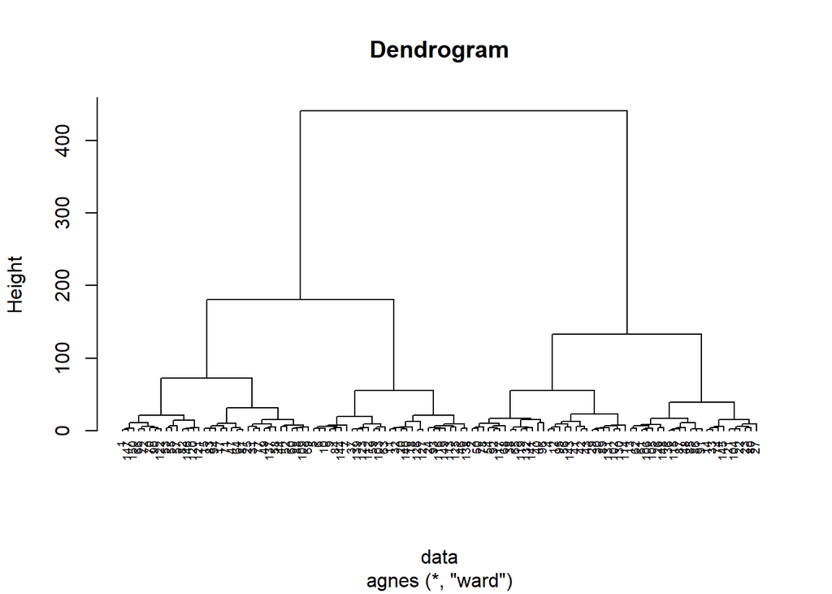

```r
clust<-agnes(data,method="ward")
## produce dendrogram
pltree(clust,cex=0.6,hang=-1,main = "Dendrogram")
```

## 3.2.Xác định số cụm

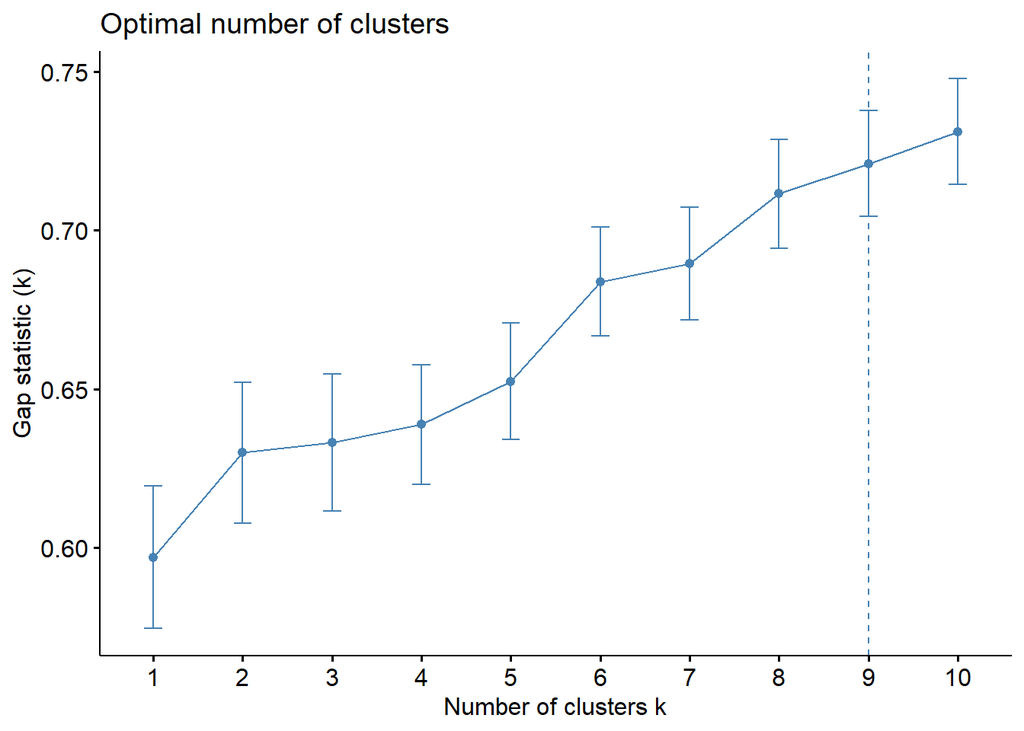

```r
# Dùng gap statistic để xác định số nhóm
gap_stats<-clusGap(data[,-1],FUN = hcut,nstart=25,K.max = 10,B=50)
fviz_gap_stat(gap_stats)
```

## 3.3.Tiến hành phân cụm và đánh giá

```r
#compute distance matrix (Tính toán ma trận khoảng cách)
d <- dist(data[,-1], method = "euclidean")

#perform hierarchical clustering using Ward's method
final_clust <- hclust(d, method = "ward.D2" )

#cut the dendrogram into 6 clusters
groups <- cutree(final_clust, k=6)
table(groups)
```

```
## groups
##  1  2  3  4  5  6
## 21 36 23  8 15 14
```

```r
final_data<-cbind(na.omit(car_sales[,1:13]),cluster=groups)
head(final_data)
```

```
##     model  sales resale type price engine_s horsepow wheelbas width length
## 1 Integra 16.919 16.360    0 21.50      1.8      140    101.2  67.3  172.4
## 2      TL 39.384 19.875    0 28.40      3.2      225    108.1  70.3  192.9
## 4      RL  8.588 29.725    0 42.00      3.5      210    114.6  71.4  196.6
## 5      A4 20.397 22.255    0 23.99      1.8      150    102.6  68.2  178.0
## 6      A6 18.780 23.555    0 33.95      2.8      200    108.7  76.1  192.0
## 7      A8  1.380 39.000    0 62.00      4.2      310    113.0  74.0  198.2
##   curb_wgt fuel_cap mpg cluster
## 1    2.639     13.2  28       1
## 2    3.517     17.2  25       2
## 4    3.850     18.0  22       2
## 5    2.998     16.4  27       3
## 6    3.561     18.5  22       2
## 7    3.902     23.7  21       4
```

```r
aggregate(final_data[,-1],by=list(cluster=final_data$cluster),mean)
```

```
##   cluster      sales   resale type    price engine_s horsepow wheelbas    width
## 1       1  55.564905 10.19905    0 13.98843 1.847619 115.4762 100.1190 67.60000
## 2       2  34.954083 20.43528    0 30.13472 3.466667 210.6944 109.1111 72.76389
## 3       3  72.795783 12.14022    0 18.75178 2.478261 152.4348 105.5087 69.90000
## 4       4   6.231125 51.40250    0 66.21563 4.750000 321.5000 103.9500 72.33750
## 5       5 119.488800 15.86433    1 24.21713 3.546667 179.6000 120.2333 75.98667
## 6       6  69.603357 16.53071    1 23.96786 3.207143 173.4286 104.6357 68.85000
##     length curb_wgt fuel_cap      mpg cluster
## 1 171.6667 2.509857 13.08095 30.28571       1
## 2 196.3194 3.550611 18.07222 23.60556       2
## 3 186.5087 3.006522 15.98261 25.65217       3
## 4 185.0625 3.592750 20.32500 20.75000       4
## 5 201.8800 4.054200 23.96667 19.66667       5
## 6 178.0071 3.548571 19.22143 20.35714       6
```

# Bài tập 4: Phân tích khác biệt

## 4.1.Tìm hiểu tình huống

-Một hãng hàng không thu thập dữ liệu về nhân viên của họ đang làm 3 loại công việc:

1. nhân viên dịch vụ khách hàng
2. công nhân kĩ thuật
3. nhân viên điều phối

-Giám đốc Nhân sự của hãng muốn biết liệu ba cách phân loại công việc này có phù hợp với các loại tính cách khác nhau của nhân viên hay không?

-Mỗi nhân viên được thực hiện một loạt bài kiểm tra tâm lý để đánh giá, đo lường về 3 loại tính cách:

1. tính cách hướng ngoại;
2. tính cách hòa đồng;
3. tính bảo thủ (khó thay đổi hoặc bị thuyết phục bởi người khác)

-Dự liệu trong tệp “discriminant_example” gồm biến:

JOB:loại công việc được phân loại;

OUTDOOR: Tính hướng ngoại;

SOCIAL: Tính hòa đồng;

CONSERVATIVE: Tính bảo thủ

Yêu cầu: Sử dụng phương pháp phân tích khác biệt để phân loại nhân viên của hãng thành 3 nhóm.

```r
library(readxl)
DAE <- read_excel("Assignment_TKT63/discriminant_example.xlsx")
```

## 4.2. Tiến hành phân tích khác biệt

```r
DAE[,-4]=scale(DAE[,-4])
set.seed(6)
sp<- sample(c(TRUE, FALSE), nrow(DAE), replace=TRUE, prob=c(0.7,0.3))
train1<-DAE[sp,-5]
test1<-DAE[!sp,-5]
```

```r
library(MASS)
model <- lda(JOB~., data=train1)
model
```

```
## Call:
## lda(JOB ~ ., data = train1)
##
## Prior probabilities of groups:
##         1         2         3
## 0.3190184 0.3987730 0.2822086
##
## Group means:
##       OUTDOOR     SOCIAL CONSERVATIVE
## 1 -0.70426084  0.6838234  -0.43700501
## 2  0.62442898  0.1601706  -0.07579491
## 3 -0.03328216 -1.0359478   0.68745775
##
## Coefficients of linear discriminants:
##                     LD1        LD2
## OUTDOOR       0.5389918 -1.0754960
## SOCIAL       -1.0528910 -0.3321711
## CONSERVATIVE  0.4337316  0.2489320
##
## Proportion of trace:
##    LD1    LD2
## 0.7462 0.2538
```

```r
predicted <- predict(model,test1 )
#predicted
print("Tỷ lệ dự báo đúng")
```

```
## [1] "Tỷ lệ dự báo đúng"
```

```r
mean(predicted$class==test1$JOB,na.rm=TRUE)
```

```
## [1] 0.7160494
```

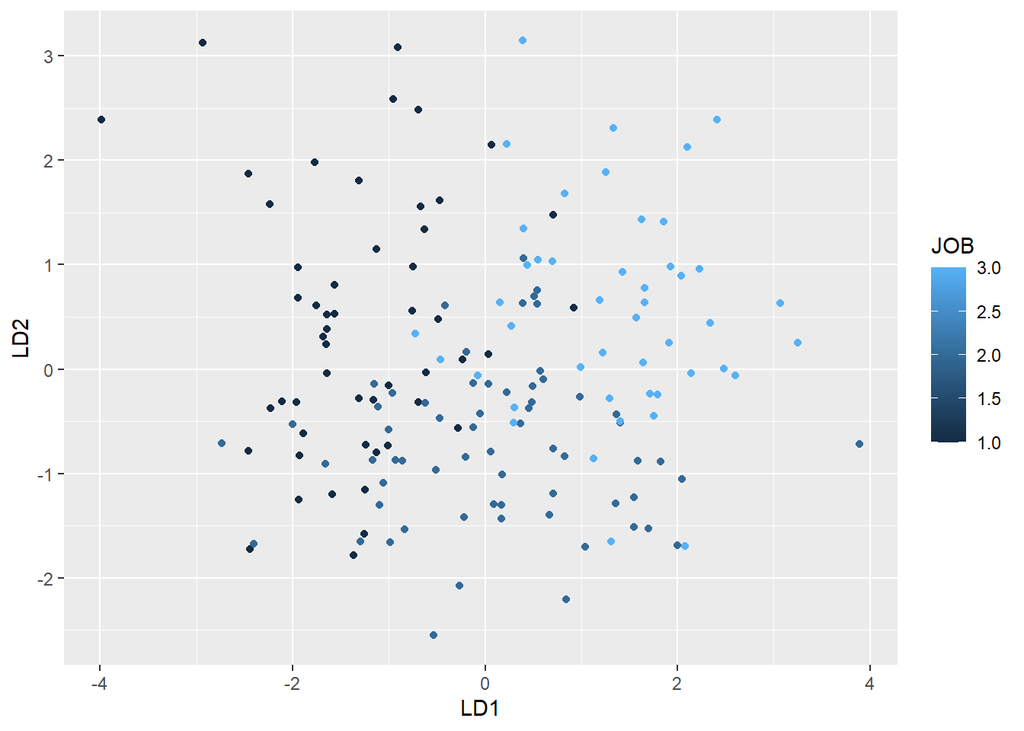

```r
lda_plot <- cbind(train1, predict(model)$x)
library(ggplot2)
ggplot(data = lda_plot, mapping=aes(LD1,LD2)) + geom_point(aes(color = JOB))
```